# Weathering Storms - which types of events are most harmful to population health or have the greatest economic consequences?

Kirsten Meeker

September 28, 2016

## Synposis

This data analysis attempts to address the following questions:  
1. Across the United States, which types of events are most harmful with respect to population health?  
2. Across the United States, which types of events have the greatest economic consequences?

## Finding the data to answer the questions

Download file from course link: https://d396qusza40orc.cloudfront.net/repdata%2Fdata%2FStormData.csv.bz2

```r
if (!file.exists("./repdata%2Fdata%2FStormData.csv.bz2")) {
    fileUrl <- "http://d396qusza40orc.cloudfront.net/repdata%2Fdata%2FStormData.csv.bz2"
    download.file(fileUrl, destfile = "./repdata%2Fdata%2FStormData.csv.bz2")
}
df = read.csv(bzfile("repdata%2Fdata%2FStormData.csv.bz2"))
```

The assignment asks for the event types across the U.S., and gives EVTYPE as the variable encoding event types. From a quick look at data, the fatalities and injuries variables would seem logical measures of harm to population health. Potential variables for measuring economic consequences are: PROPDMG, CROPDMG (numbers) and PROPDMGEXP, CROPDMGEXP (factors). Potential location variables include: COUNTY (number), COUNTYNAME (factor), STATE (factor), BGN & END RANGE, AZI, LOCATI (all factors), STATEOFFIC, ZONENAMES (factors), LATITUDE, LONGITUDE, LATITUDE_E, and LONGITUDE_ (all numbers).

### From the FAQ:

(https://d396qusza40orc.cloudfront.net/repdata%2Fpeer2_doc%2FNCDC%20Storm%20Events-FAQ%20Page.pdf)

- Storm data is entered into the database as a distance in miles and a direction on 16-point compass scale from a known location, usually a town or city.
- Property and crop damage is a best guess made by the National Weather Service using all the data available at the time.
- For events that include a fatality, there is a code containing the gender, age and fatality location at the end of the event narrative.
- An Episode is an entire storm system and can contain many different types of events. An Event is an individual type of storm event. (Thunderstorm Wind, Hail, Tornado and Flood are events)

### From STORM DATA PREPARATION INSTRUCTION:

(https://d396qusza40orc.cloudfront.net/repdata%2Fpeer2_doc%2Fpd01016005curr.pdf)  
NATIONAL WEATHER SERVICE INSTRUCTION 10-1605  
AUGUST 17, 2007  
Operations and Services  
Performance, NWSPD 10-16  
STORM DATA PREPARATION

- Section 2.1.1 contains a Storm Data Event Table which gives the types of events which are recorded. They are associated with three designators: C - County/Parish; Z - Zone; and M - Marine.
- Section 2.6.1.2 gives a Direct Fatality Location Table.
- Property damage estimates should be entered as actual dollar amounts.

Who is the customer? What location data should be used: county, state, zone? The project instructions include: “Consider writing your report as if it were to be read by a government or municipal manager who might be responsible for preparing for severe weather events and will need to prioritize resources for different types of events.” I’d imagine that storm episodes do not abide by geopolitical boundaries, so zone might be most approriate for clustering storms. However, since the user would probably be state or county governments, they would want to know if they were either directly effected or in a position to offer neighborly aid.

## Data Processing

### Exploration

Rank EVTTYPE by FATALITIES & INJURIES and then by PROPDMG & CROPDMG. Pie charts? How to add location? How many locations are there? Can they be grouped by rankings?

Explore location variables:

```r
summary(df$STATE)
```

```
##    AK    AL    AM    AN    AR    AS    AZ    CA    CO    CT    DC    DE
##  4391 22739  1879  3250 27102   257  6156 10780 20473  3294   437  1913
##    FL    GA    GM    GU    HI    IA    ID    IL    IN    KS    KY    LA
## 22124 25259  5337   306  2547 31069  4767 28488 21506 53440 22092 17323
##    LC    LE    LH    LM    LO    LS    MA    MD    ME    MH    MI    MN
##   274  1526   654  1347    70   262  5652  8185  4524     1 17910 23609
##    MO    MS    MT    NC    ND    NE    NH    NJ    NM    NV    NY    OH
## 35648 22192 14695 25351 14632 30271  3022  8075  7129  3139 21058 24922
##    OK    OR    PA    PH    PK    PM    PR    PZ    RI    SC    SD    SL
## 46802  4821 22226    28    23     1  3015    96   839 17126 21727     7
##    ST    TN    TX    UT    VA    VI    VT    WA    WI    WV    WY    XX
##     1 21721 83728  4135 21189   338  3871  3312 19781  9099  7332     2
```

```r
summary(df$COUNTYNAME)
```

```
##  JEFFERSON WASHINGTON    JACKSON   FRANKLIN    LINCOLN    MADISON
##       7840       7603       6660       6256       5937       5632
## MONTGOMERY     MARION       POLK       CLAY     MONROE    JOHNSON
##       5398       4779       4629       4517       4175       3759
##      WAYNE      UNION     GREENE       CASS      GRANT     WARREN
##       3726       3678       3466       3340       3333       3324
##   MARSHALL     BUTLER   CRAWFORD   HAMILTON      LOGAN    CARROLL
##       3091       3080       3067       3064       3038       3020
##      CLARK   LAWRENCE    DOUGLAS      ADAMS      SCOTT        LEE
##       3011       2999       2985       2898       2889       2849
##     SHELBY     MORGAN   CHEROKEE    PULASKI     DALLAS      BROWN
##       2832       2793       2701       2690       2678       2603
##    FAYETTE   RICHLAND       KNOX      BOONE     CUSTER   HARRISON
##       2551       2402       2397       2353       2323       2234
##     JASPER       PIKE      HENRY     ORANGE     BENTON      CADDO
##       2219       2219       2213       2197       2161       2083
##    CLINTON    WEBSTER   DELAWARE     HOWARD     FULTON      OSAGE
##       2083       1996       1963       1962       1944       1933
##   SEDGWICK     SALINE    CALHOUN      ELLIS       YORK    TARRANT
##       1926       1881       1880       1853       1835       1825
##     PUTNAM     MERCER      JONES       LAKE   COMANCHE   GARFIELD
##       1809       1785       1752       1740       1727       1726
## CUMBERLAND   COLUMBIA      PERRY     TAYLOR   ANDERSON      KIOWA
##       1714       1713       1713       1705       1679       1657
##    HANCOCK     NEWTON  ST. LOUIS              RANDOLPH      MEADE
##       1652       1637       1603       1589       1577       1568
##    EL PASO   CHEYENNE   OKLAHOMA  ST. CLAIR     HARRIS      SMITH
##       1549       1539       1526       1498       1494       1465
##      FLOYD      TULSA LAUDERDALE  LANCASTER  CLEVELAND     OTTAWA
##       1462       1462       1438       1437       1429       1386
##     CARTER       COOK   CAMPBELL   SHERIDAN      WHITE       FORD
##       1370       1341       1340       1331       1322       1290
##     POTTER  LAFAYETTE       ERIE    (Other)
##       1290       1287       1282     651640
```

Other than 2 “XX” state entries the state entries look fairly complete. County entries have 651640 of 902297 observations (72%) categorized as “other.” Looks like state would be a reasonable start.

How many event types occur in each state? Group data by state and count number of event types EVTTYPE for each.

```r
require(plyr)
evts_per_state = ddply(df, "STATE", summarise,
               NumEvnts = length(unique(EVTYPE))
)
max(evts_per_state$NumEvnts)
```

```
## [1] 143
```

The maximum number of event types is large, so it might be a challenge to visualize the ranking of them all! Let’s see how they rank by health harm & economic damage.

```r
require(plyr)
library(dplyr)
sum_by_state_evtype = ddply(df, c("STATE","EVTYPE"), summarise,
               NumEvtype    = length(EVTYPE),
               EvtypeFatalities = sum(FATALITIES),
               EvtypeInjuries = sum(INJURIES),
               EvtypeTotalHealth = sum(FATALITIES) + sum(INJURIES),
               EvtypePropDmg = sum(PROPDMG),
               EvtypeCropDmg = sum(CROPDMG),
               EvtypeTotalDmg = sum(PROPDMG) + sum(CROPDMG)
)

health_by_state_evtype = arrange(sum_by_state_evtype[sum_by_state_evtype$EvtypeTotalHealth>0,], STATE, desc(EvtypeTotalHealth))

dmg_by_state_evtype = arrange(sum_by_state_evtype[sum_by_state_evtype$EvtypeTotalDmg>0,], STATE, desc(EvtypeTotalDmg))

# select top 5
top5_health_by_state_evtype = health_by_state_evtype %>%
  arrange_(~ desc(EvtypeTotalHealth)) %>%
  group_by_(~ STATE) %>%
  slice(1:5)

top5_dmg_by_state_evtype = dmg_by_state_evtype %>%
  arrange_(~ desc(EvtypeTotalDmg)) %>%
  group_by_(~ STATE) %>%
  slice(1:5)
```

## Results

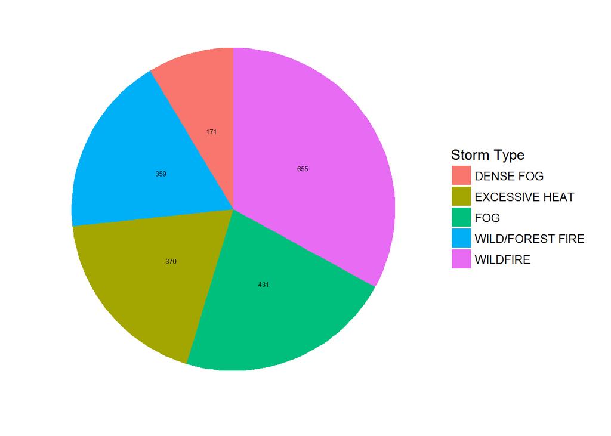

```r
library(ggplot2)
library(scales)
blank_theme <- theme_minimal()+
  theme(
  axis.title.x = element_blank(),
  axis.title.y = element_blank(),
  panel.border = element_blank(),
  panel.grid=element_blank(),
  axis.ticks = element_blank(),
  plot.title=element_text(size=14, face="bold"),
  axis.text.x=element_blank()
  )

state = "CA"
ca_top5_health = top5_health_by_state_evtype[top5_health_by_state_evtype$STATE==state,]
ggplot(ca_top5_health, aes(x="",y=EvtypeTotalHealth, fill=EVTYPE))+
    geom_bar(width = 1, stat = "identity")+
    coord_polar("y", start=0)+
    blank_theme+
    geom_text(aes(y=cumsum(EvtypeTotalHealth)-0.5*EvtypeTotalHealth, label = EvtypeTotalHealth), size=2)+
    scale_fill_discrete(name="Storm Type")
```

```r
paste("Top 5 Storm Types with Health Impact for",state)
```

```
## [1] "Top 5 Storm Types with Health Impact for CA"
```

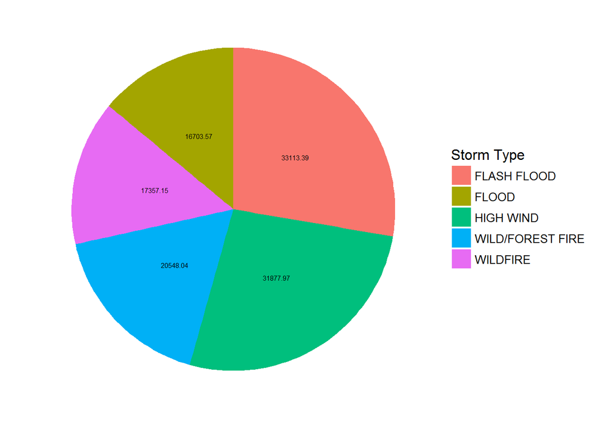

```r
ca_top5_dmg = top5_dmg_by_state_evtype[top5_dmg_by_state_evtype$STATE==state,]
ggplot(ca_top5_dmg, aes(x="",y=EvtypeTotalDmg, fill=EVTYPE))+
    geom_bar(width = 1, stat = "identity")+
    coord_polar("y", start=0)+
    blank_theme+
    geom_text(aes(y=cumsum(EvtypeTotalDmg)-0.5*EvtypeTotalDmg, label = EvtypeTotalDmg), size=2)+
    scale_fill_discrete(name="Storm Type")
```

```r
paste("Top 5 Storm Types with Economic Impact for",state)
```

```
## [1] "Top 5 Storm Types with Economic Impact for CA"
```